# White Wine Quality by Reem Tarek

#### This dataset is public available for research. The details are described in [Cortez et al., 2009].

#### Please include this citation if you plan to use this database:

#### P. Cortez, A. Cerdeira, F. Almeida, T. Matos and J. Reis.

#### Modeling wine preferences by data mining from physicochemical properties.

#### In Decision Support Systems, Elsevier, 47(4):547-553. ISSN: 0167-9236.

#### Available at: [@Elsevier] http://dx.doi.org/10.1016/j.dss.2009.05.016

#### [Pre-press (pdf)] http://www3.dsi.uminho.pt/pcortez/winequality09.pdf

#### [bib] http://www3.dsi.uminho.pt/pcortez/dss09.bib

#### Number of Instances: 4898 records for white wine.

```r
#install.packages("ggplot2", repos = "http://cran.us.r-project.org")
#install.packages("knitr",repos="http://cran.us.r-project.org")
##install.packages("dplyr",repos="http://cran.us.r-project.org")
#install.packages("rmarkdown",repos="http://cran.us.r-project.org")
#install.packages('rprojroot', repos="http://cran.us.r-project.org")
#install.packages("psych",repos="http://cran.us.r-project.org")
```

```r
library(ggplot2)
library(knitr)
library(dplyr)
library(rmarkdown)
library(psych)
```

This dataset consists of 4898 obseration of white wine and its quality rating as stated by some of the wine tasters world wide.  
it has 11 variables:  
Input variables (based on physicochemical tests):  
1 - fixed acidity (tartaric acid - g / dm^3)  
2 - volatile acidity (acetic acid - g / dm^3)  
3 - citric acid (g / dm^3)  
4 - residual sugar (g / dm^3)  
5 - chlorides (sodium chloride - g / dm^3  
6 - free sulfur dioxide (mg / dm^3)  
7 - total sulfur dioxide (mg / dm^3)  
8 - density (g / cm^3)  
9 - pH  
10 - sulphates (potassium sulphate - g / dm3)  
11 - alcohol (% by volume)  
Output variable (based on sensory data):  
12 - quality (score between 0 and 10)  
No missing values are found.  
Description of attributes:  
1 - fixed acidity: most acids involved with wine or fixed or nonvolatile (do not evaporate readily)  
2 - volatile acidity: the amount of acetic acid in wine, which at too high of levels can lead to an unpleasant, vinegar taste  
3 - citric acid: found in small quantities, citric acid can add ‘freshness’ and flavor to wines  
4 - residual sugar: the amount of sugar remaining after fermentation stops, it’s rare to find wines with less than 1 gram/liter and wines with greater than 45 grams/liter are considered sweet  
5 - chlorides: the amount of salt in the wine  
6 - free sulfur dioxide: the free form of SO2 exists in equilibrium between molecular SO2 (as a dissolved gas) and bisulfite ion; it prevents microbial growth and the oxidation of wine  
7 - total sulfur dioxide: amount of free and bound forms of S02; in low concentrations, SO2 is mostly undetectable in wine, but at free SO2 concentrations over 50 ppm, SO2 becomes evident in the nose and taste of wine  
8 - density: the density of water is close to that of water depending on the percent alcohol and sugar content  
9 - pH: describes how acidic or basic a wine is on a scale from 0 (very acidic) to 14 (very basic); most wines are between 3-4 on the pH scale  
10 - sulphates: a wine additive which can contribute to sulfur dioxide gas (S02) levels, wich acts as an antimicrobial and antioxidant  
11 - alcohol: the percent alcohol content of the wine  
12 - quality (score between 0 and 10)

# Univariate Plots Section

```
##  [1] "X"                    "fixed.acidity"        "volatile.acidity"
##  [4] "citric.acid"          "residual.sugar"       "chlorides"
##  [7] "free.sulfur.dioxide"  "total.sulfur.dioxide" "density"
## [10] "pH"                   "sulphates"            "alcohol"
## [13] "quality"
```

#### Summary:

#### Facotrized the quality into categorical rating for the upcoming analysis

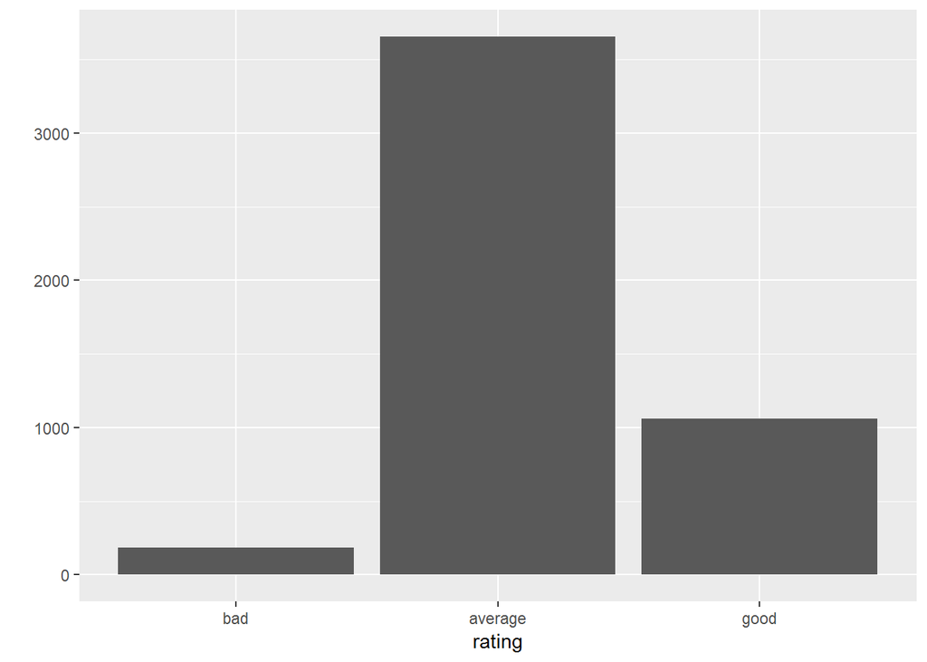

#### Summary:

#### Plotted a Histogram of the derived ratings

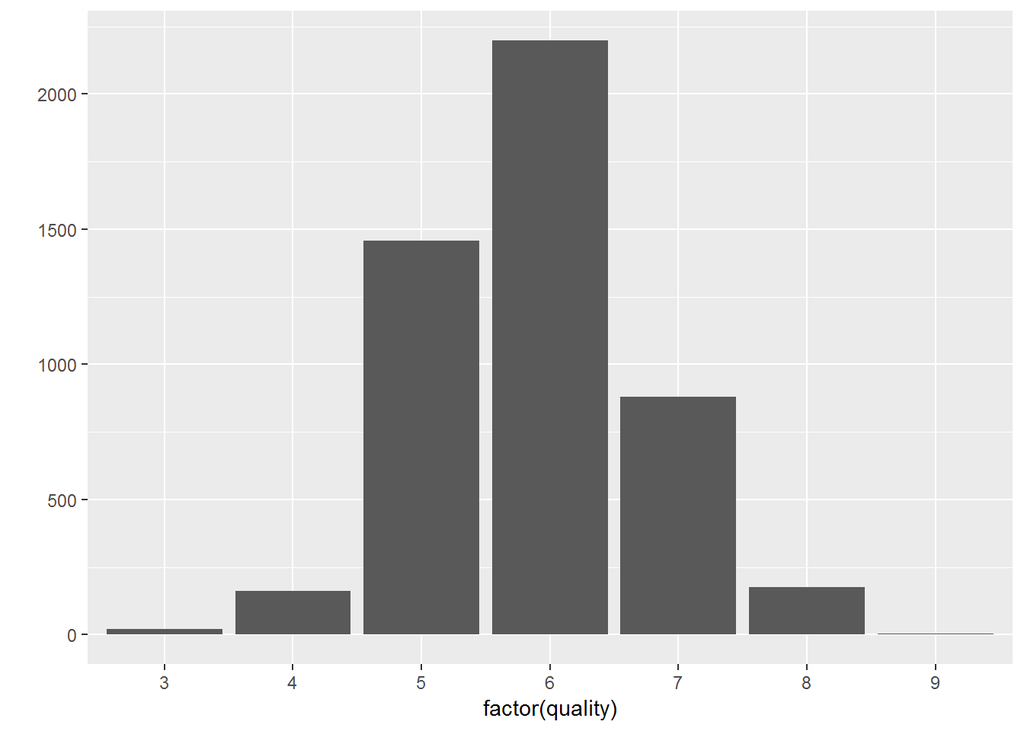

#### Summary:

#### Plotted a Histogram of the quality, it is normally distributed with a median of 6.

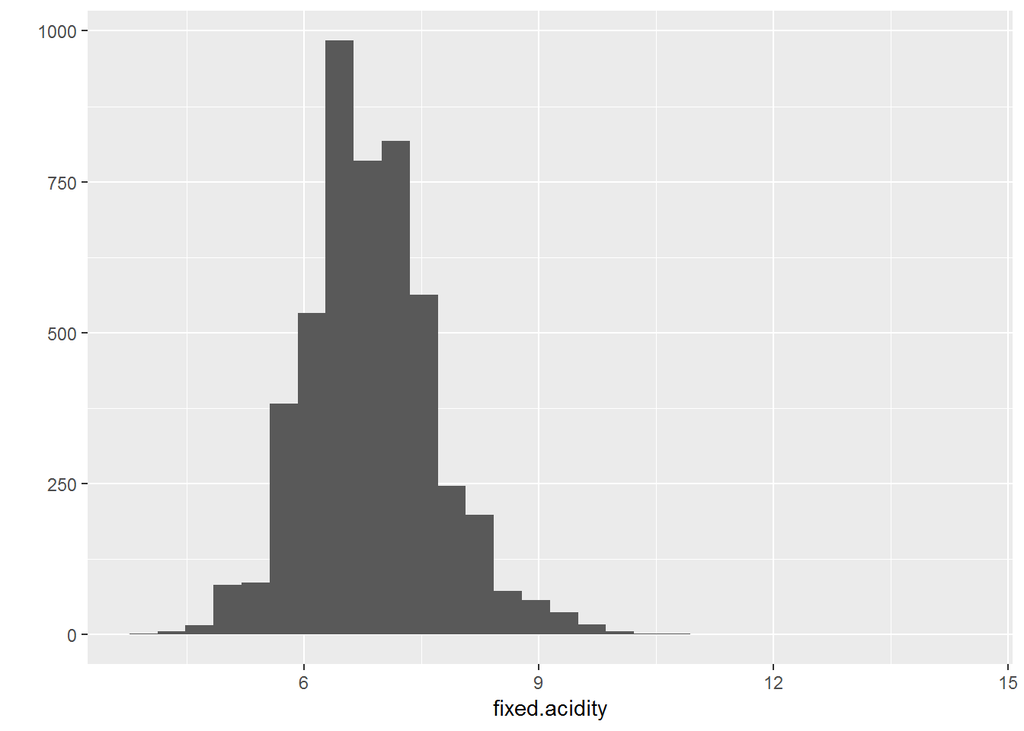

```
##    Min. 1st Qu.  Median    Mean 3rd Qu.    Max.
##   3.800   6.300   6.800   6.855   7.300  14.200
```

#### Summmay:

#### Fixed Acidity is normally distributed with mean of 6.9

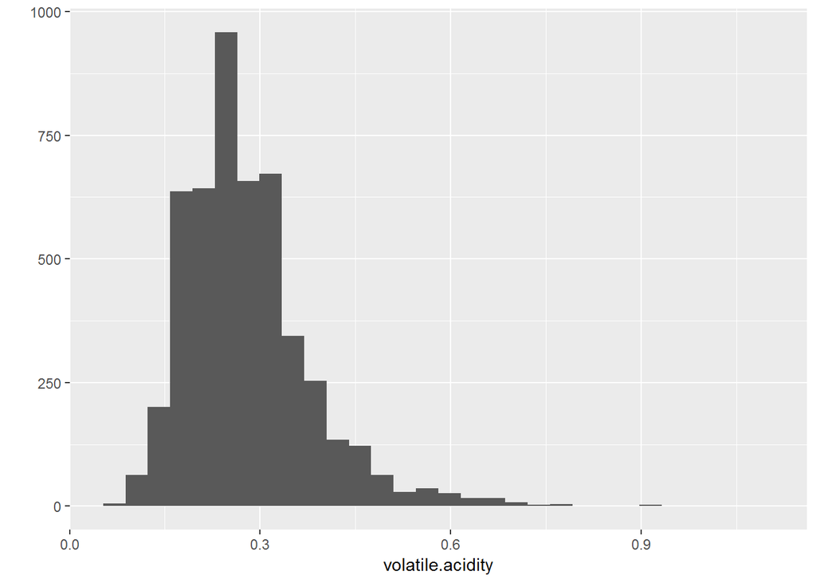

```
##    Min. 1st Qu.  Median    Mean 3rd Qu.    Max.
##  0.0800  0.2100  0.2600  0.2782  0.3200  1.1000
```

#### Summary:

#### Volatile Acidity is normally distributed with a mean of 0.28

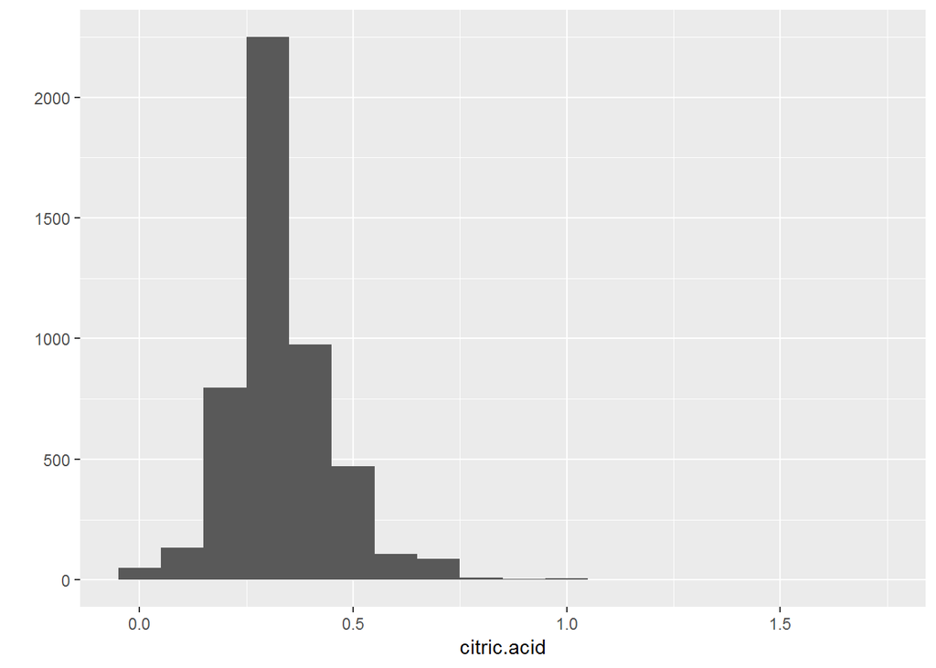

```
##    Min. 1st Qu.  Median    Mean 3rd Qu.    Max.
##  0.0000  0.2700  0.3200  0.3342  0.3900  1.6600
```

#### Summary:

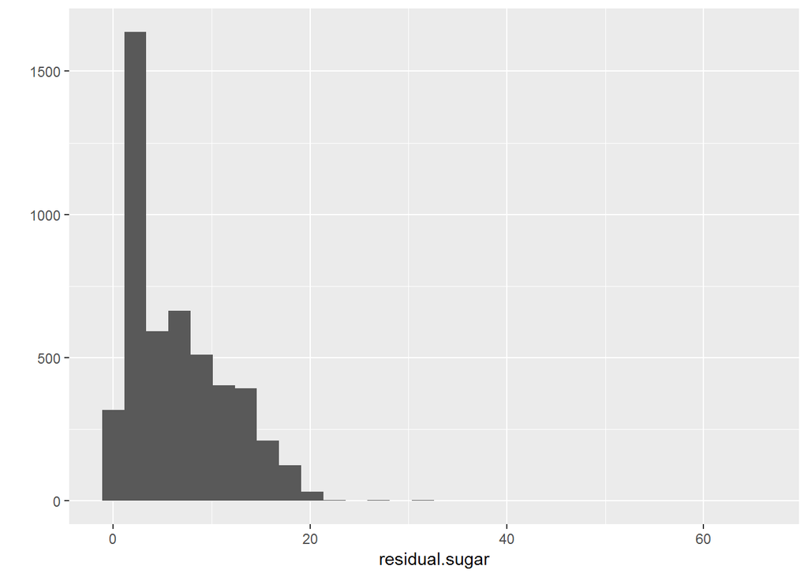

```
##    Min. 1st Qu.  Median    Mean 3rd Qu.    Max.
##   0.600   1.700   5.200   6.391   9.900  65.800
```

#### Summary:

#### Residual sugar could have been normally distributed but it has a peek values in the frst Quad

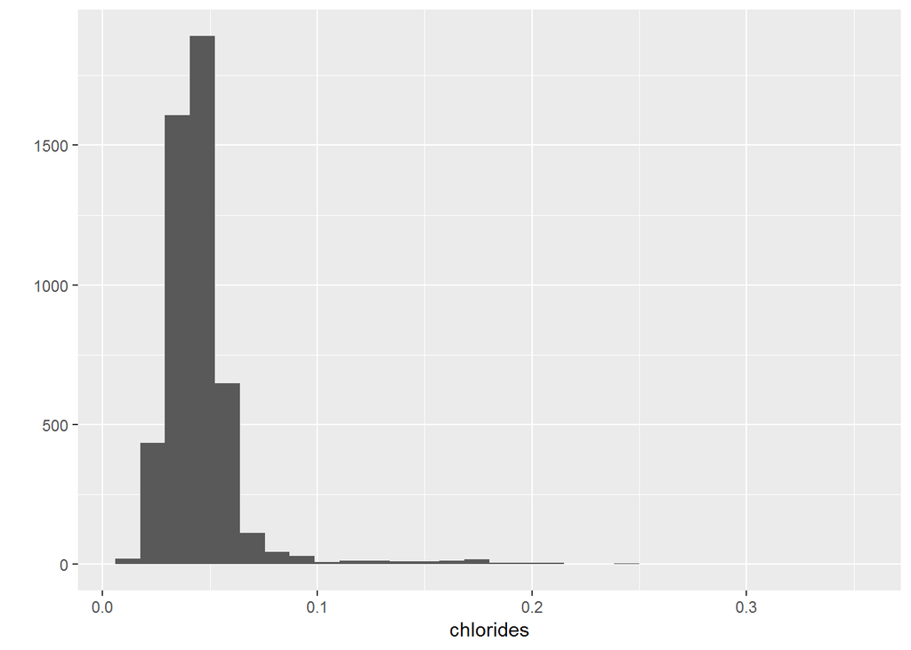

```
##    Min. 1st Qu.  Median    Mean 3rd Qu.    Max.
## 0.00900 0.03600 0.04300 0.04577 0.05000 0.34600
```

#### Summary:

#### Chlorides are normally distributed with mean of 0.046

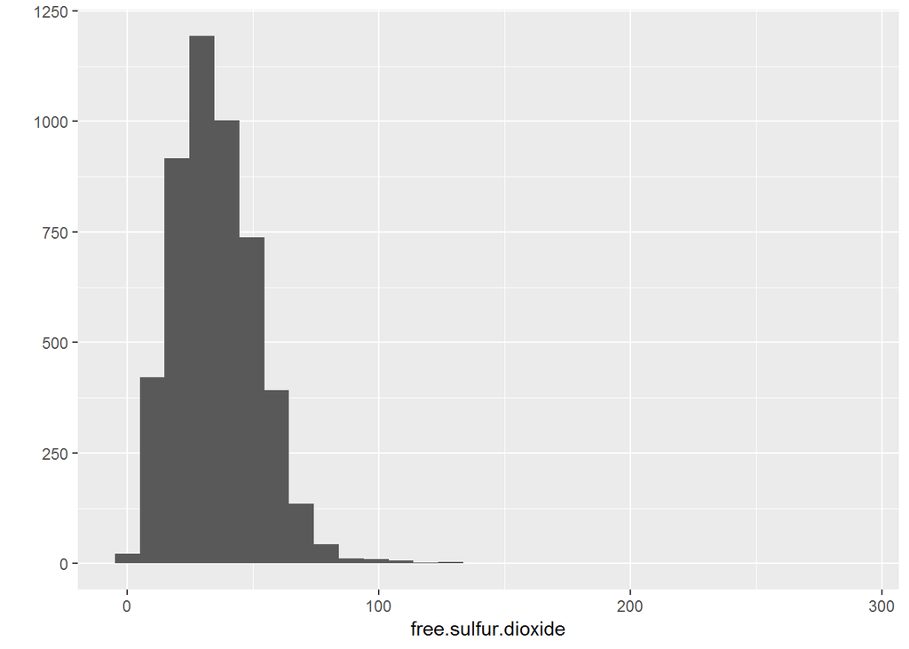

```
##    Min. 1st Qu.  Median    Mean 3rd Qu.    Max.
##    2.00   23.00   34.00   35.31   46.00  289.00
```

#### Summary:

#### Free Sulfur Dioxide is normally distributed with mean 35.31

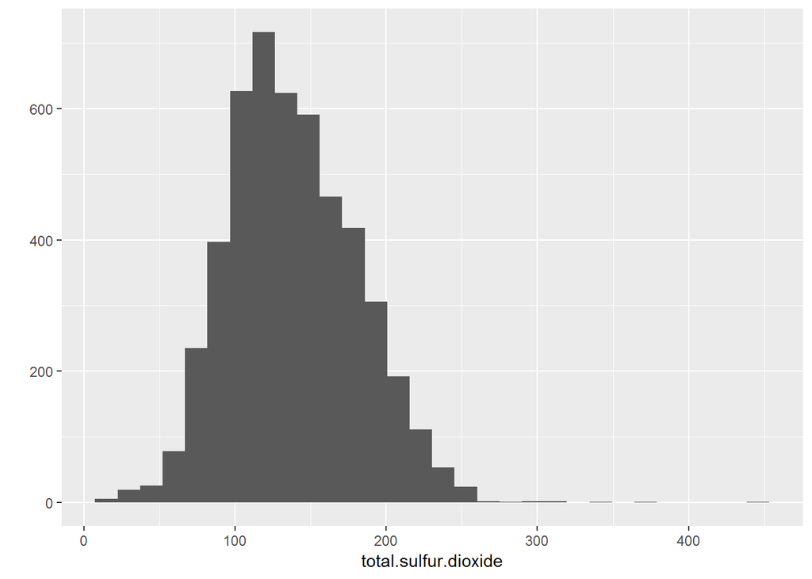

```
##    Min. 1st Qu.  Median    Mean 3rd Qu.    Max.
##     9.0   108.0   134.0   138.4   167.0   440.0
```

#### Summary:

#### Total SulfurDioxide is normally distributed wih mean of 138.

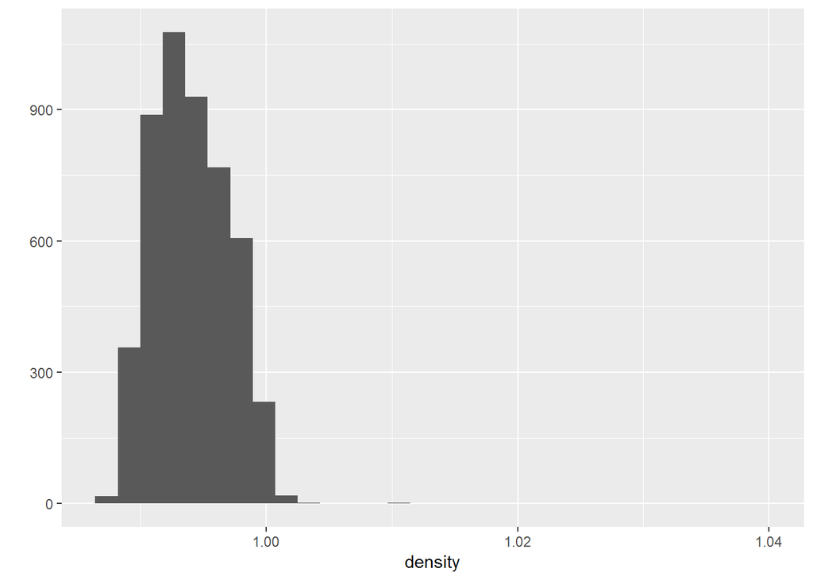

```
##    Min. 1st Qu.  Median    Mean 3rd Qu.    Max.
##  0.9871  0.9917  0.9937  0.9940  0.9961  1.0390
```

#### Summary

#### Density is normally distributed with mean of 0.99

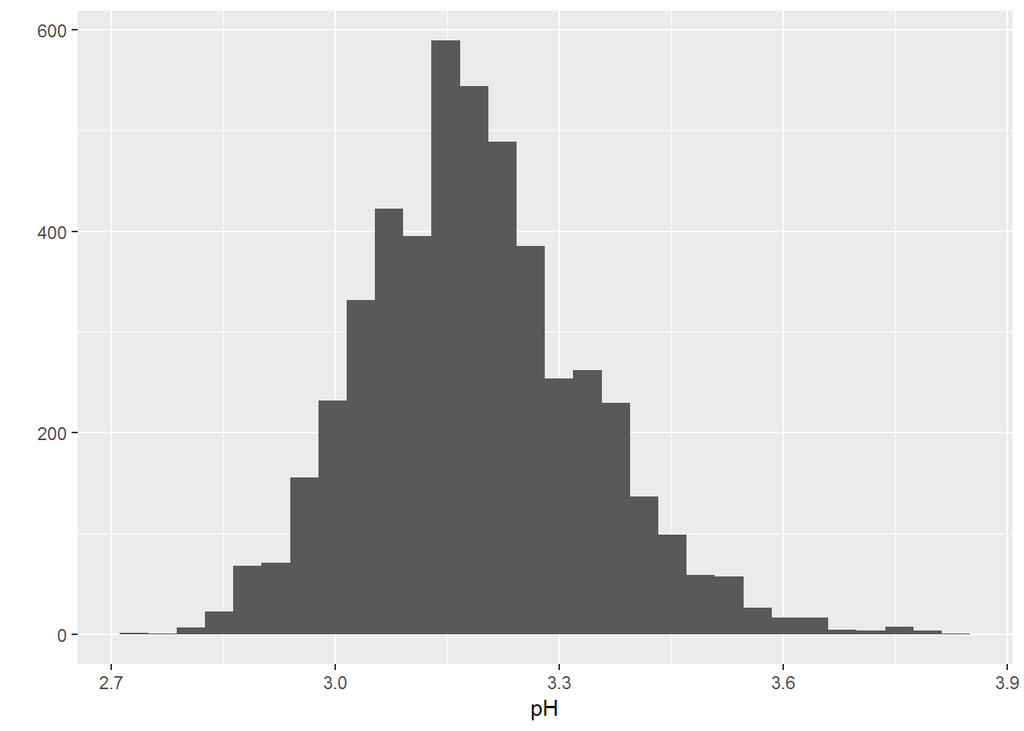

```
##    Min. 1st Qu.  Median    Mean 3rd Qu.    Max.
##   2.720   3.090   3.180   3.188   3.280   3.820
```

#### Summary

#### PH value is normally distributed with mean values 3.18, note that acid has PH valu < 6 as part of their chemical properties

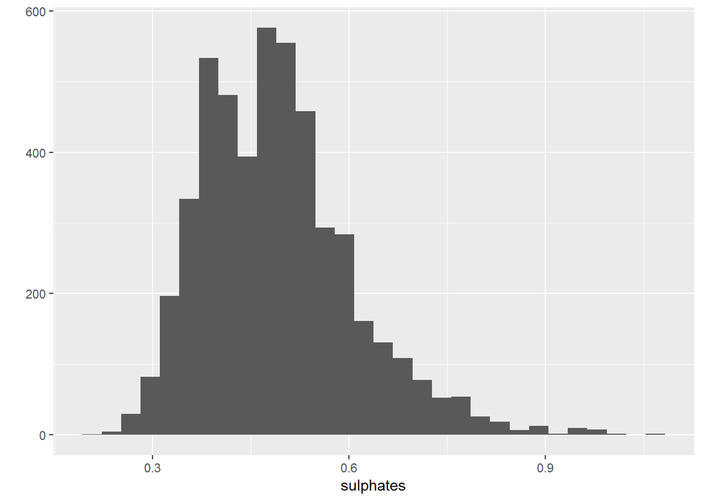

```
##    Min. 1st Qu.  Median    Mean 3rd Qu.    Max.
##  0.2200  0.4100  0.4700  0.4898  0.5500  1.0800
```

#### Summary

#### Sulphates is almost normally distributed, but it has two peeks.

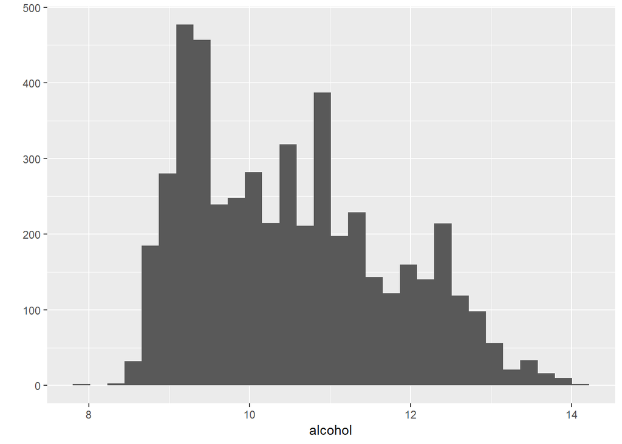

```
##    Min. 1st Qu.  Median    Mean 3rd Qu.    Max.
##    8.00    9.50   10.40   10.51   11.40   14.20
```

#### Summary

#### Alcohol is not normally distributed and it has several peeks

# Univariate Analysis

#### What is the structure of your dataset?

The Dataset consists of almost 5000 records of different white wine samples. it has 11 variables and the quality stated for each one. I have added the column rating based on the quality, the rating includes bad, average and good as a categorical classification of the data.

#### What is/are the main feature(s) of interest in your dataset?

1 - fixed acidity: most acids involved with wine or fixed or nonvolatile (do not evaporate readily)  
2 - volatile acidity: the amount of acetic acid in wine, which at too high of levels can lead to an unpleasant, vinegar taste  
3 - citric acid: found in small quantities, citric acid can add ‘freshness’ and flavor to wines  
4 - residual sugar: the amount of sugar remaining after fermentation stops, it’s rare to find wines with less than 1 gram/liter and wines with greater than 45 grams/liter are considered sweet  
5 - chlorides: the amount of salt in the wine  
6 - free sulfur dioxide: the free form of SO2 exists in equilibrium between molecular SO2 (as a dissolved gas) and bisulfite ion; it prevents microbial growth and the oxidation of wine  
7 - total sulfur dioxide: amount of free and bound forms of S02; in low concentrations, SO2 is mostly undetectable in wine, but at free SO2 concentrations over 50 ppm, SO2 becomes evident in the nose and taste of wine  
8 - density: the density of water is close to that of water depending on the percent alcohol and sugar content  
9 - pH: describes how acidic or basic a wine is on a scale from 0 (very acidic) to 14 (very basic); most wines are between 3-4 on the pH scale  
10 - sulphates: a wine additive which can contribute to sulfur dioxide gas (S02) levels, wich acts as an antimicrobial and antioxidant  
11 - alcohol: the percent alcohol content of the wine  
12 - quality (score between 0 and 10)

#### Of the features you investigated, were there any unusual distributions? Did you perform any operations on the data to tidy, adjust, or change the form of the data? If so, why did you do this?

# Bivariate Plots Section

#### Summary:

#### As part of the bivariate analysis, the correlation between the variables should be calulated to define the strength and direction of the relationships between the variables.

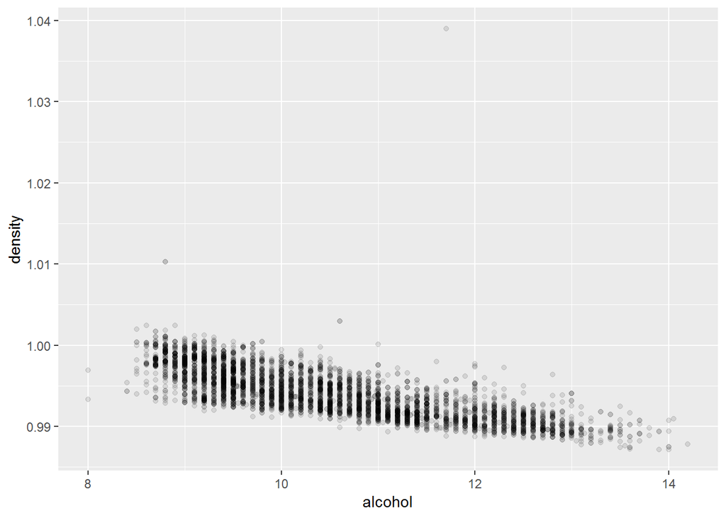

#### Summary:

#### one of the most interesting bivariate relationships is the alcohol-density one,before plotting it, I expected that as much as the alcohol increases the density decreases and that was proved to be totally correct through the plot and the correltion value:-0.780

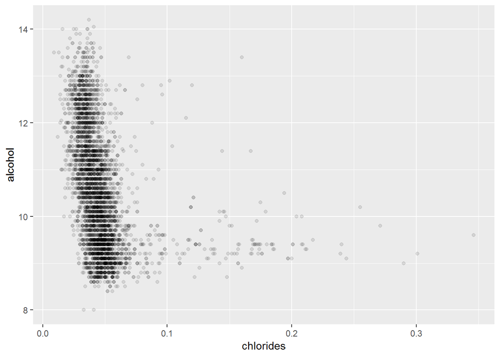

#### Summary:

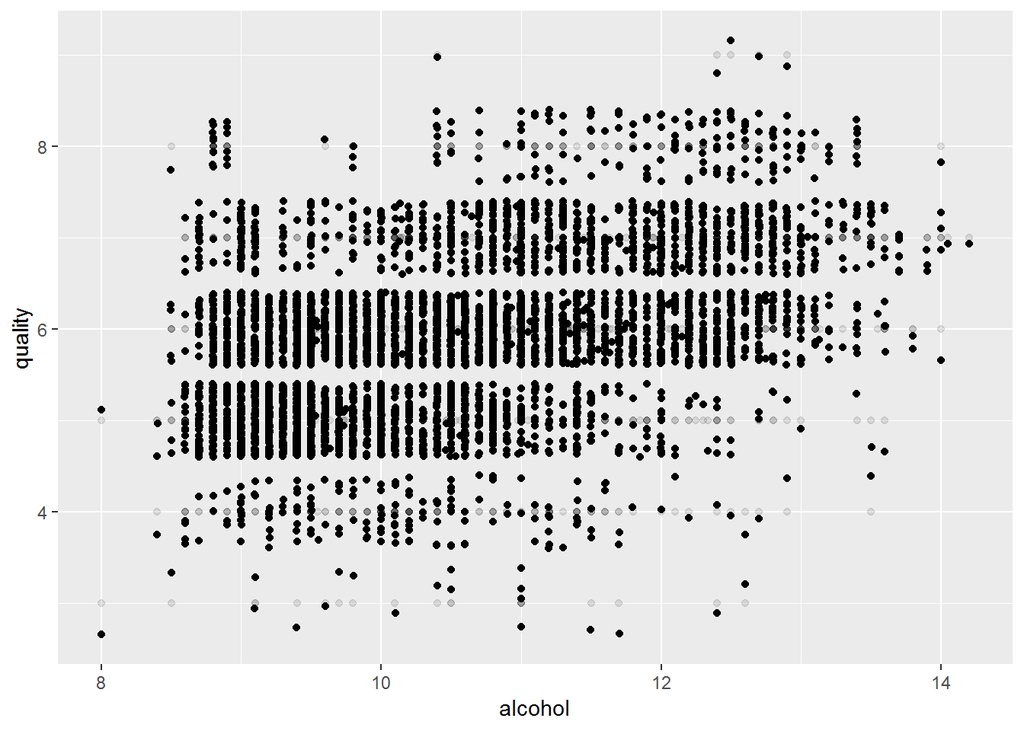

#### Summary

#### prior to the plot, I thought there is no significant relationship between the quality and alcohol,

#### butlooks like, I was wrong, there is a correlation of 0.4 between boht of them.

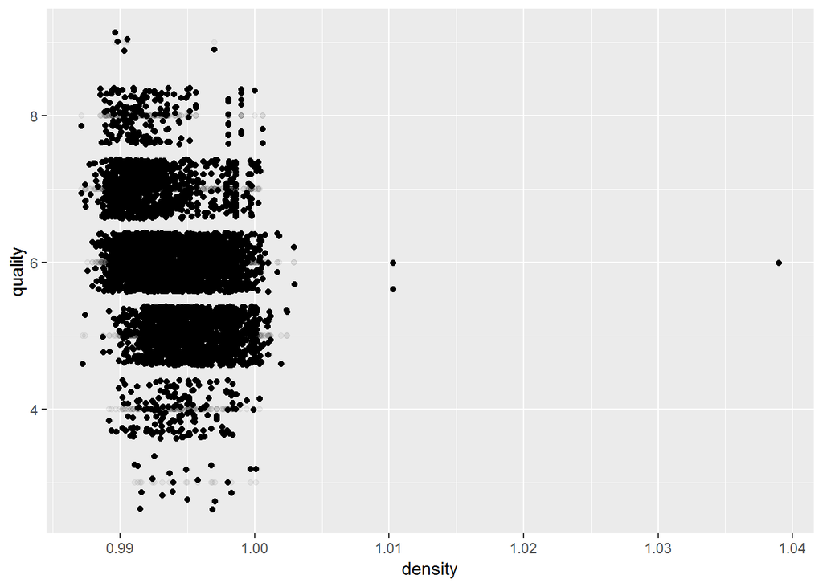

#### Summary:

#### Quality and density sort of have a mild negative relationship with correlation of -0.307123313

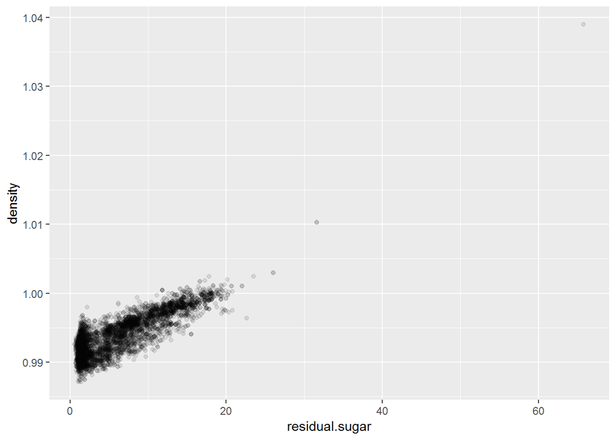

#### Summary:

#### Prior to the plot, the more you add sugar to a liquid, the higher its density gets, the plot proved this true strong positive correlation 0.83896645

# Bivariate Analysis

#### Talk about some of the relationships you observed in this part of the investigation. How did the feature(s) of interest vary with other features in the dataset?

the highest correlation in general happens to be between: 1- Density and Alcohol, the more you add the alcohol, the less dense the wine becomes (-0.78) 2- Density and Residual Sugar, the more the sugar is added the denser the wine gets (0.83) 3- Also there is a correlation between Total Sulfur Dioxide and Residual Sugar, Density and Free Sulfur Dioxide with the values (0.4, 0.5298, 0.615) respectively

#### Did you observe any interesting relationships between the other features (not the main feature(s) of interest)?

there is a correlation between Total Sulfur Dioxide and Residual Sugar, Density and Free Sulfur Dioxide with the values (0.4, 0.5298, 0.615) respectively

#### What was the strongest relationship you found?

Density and Residual Sugar, the more the sugar is added the denser the wine gets (0.83)

# Multivariate Analysis

#### Talk about some of the relationships you observed in this part of the investigation. Were there features that strengthened each other in terms of looking at your feature(s) of interest?

- Wine with higher levels of alcohol appears to be of high quality, regardless of the density and the amount of sugar.
- Wine does not really depend on the acids

### Plot One

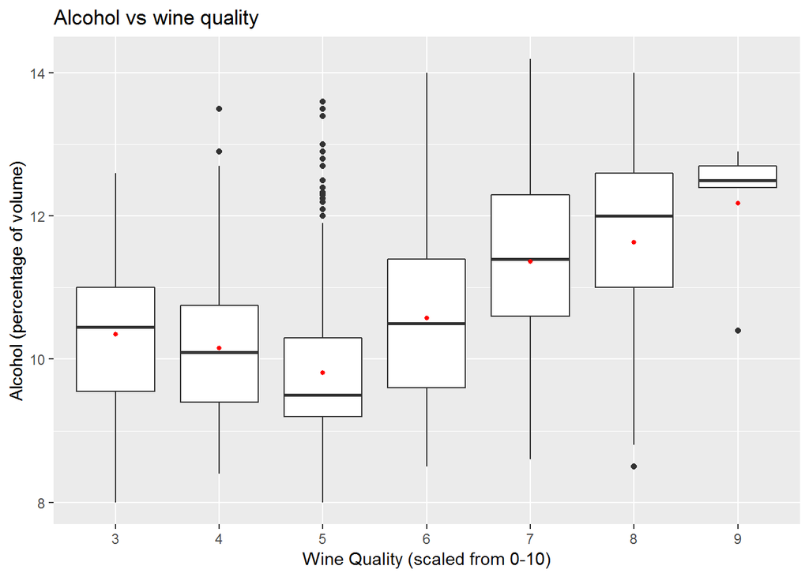

### Plot Two

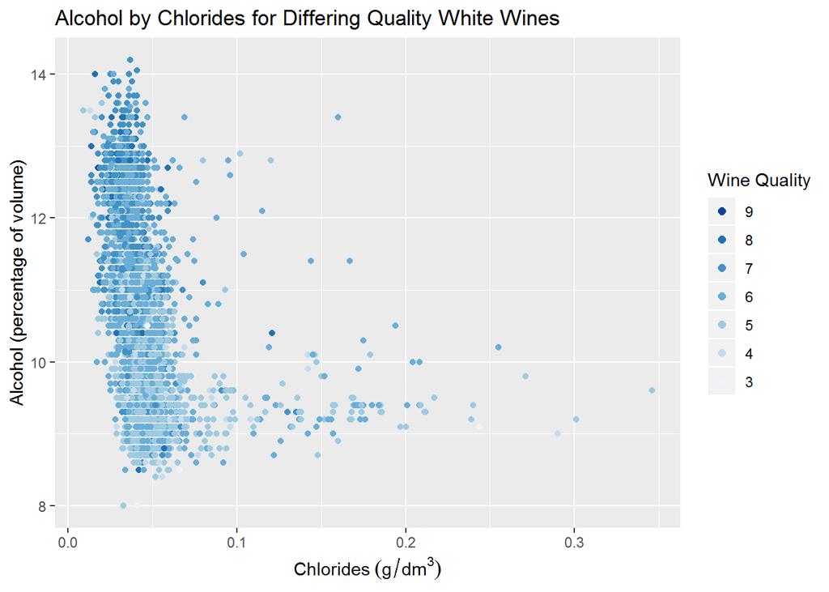

#### Plot Three

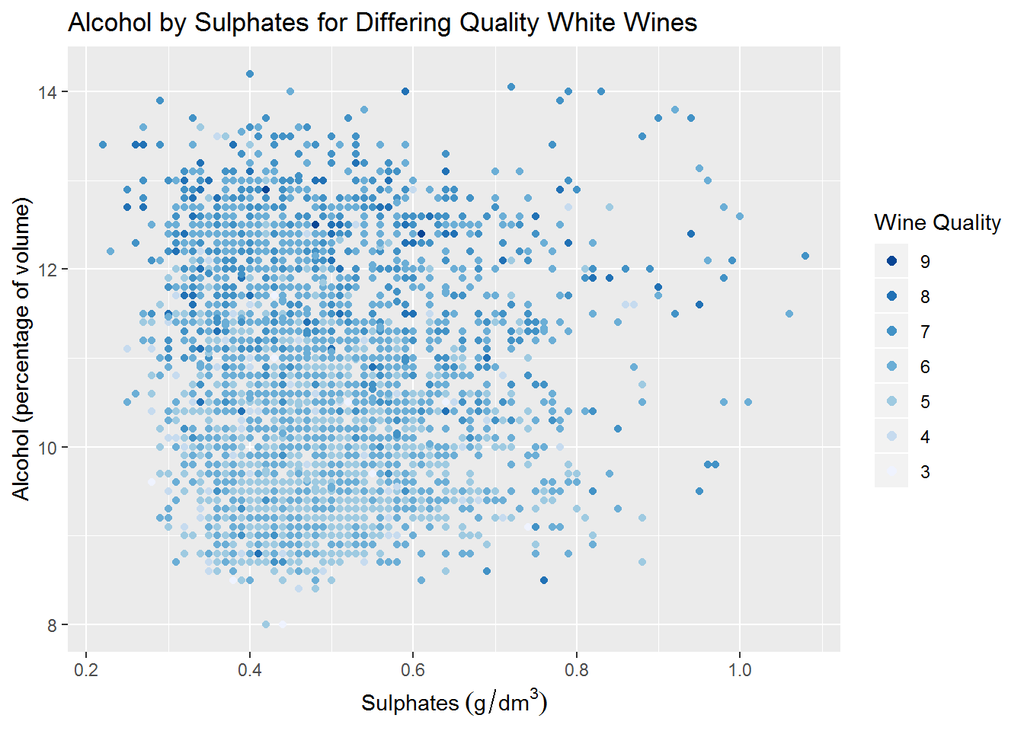

# Reflection

I think this was a good way to start, and I tried not to spend too much time experimenting with variables that didn’t have an obvious correlation. So I was succesful with most obvious correlations, or looking at trends that had the highest correlation coefficient. I had struggles with the variables relating to sulfur dioxide or whenever I tried to create a new variable to reveal latent trends or better visual trends already apparent.  
in the future, I think I might add the red wine dataset to the analysis, expermint the same on it alone and then both dataset againt each other.